# FinalProject

Rich Pihlstrom

2023-04-27

```r
library(tidyverse)
library(boot)
library(caret)
library(car)
library(ROCR)
```

# Linear Regression

## Upload Data

```r
df <- read.delim("bank.data.1.csv", sep = ",")
df <- df[,!names(df) %in% c("OTSREGNM_","SPECGRPN_")]
```

## Create Levels For Categorical Variables

### Replacement Function

The function below takes the input vectors of column names and category names with binary encoding and returns a single vector of category values.

```r
level <- function(NAME, colNames, catNames){

  colList <- c()
  removeList <- c()

  for(i in seq(1,nrow(df))){
    j <- 1
    for(name in colNames){
      if(df[i,name] == 1){
        colList <- append(colList, catNames[j])
        break
      }
      if(j == length(colNames)){
        removeList <- append(removeList, i)
      }
      j <- j+1
    }
  }

  if(length(removeList)>0){
    df <- df[-removeList,]
  }
  df <- df[,!names(df) %in% colNames]
  df[NAME] <- colList

  return(df)

}
```

### Running Function

The following sets of columns correlate to the binary one-hot encoding of a categorical variable from the original dataset:

- OTSREGNM:
  - OTSREGNM_Central
  - OTSREGNM_Northeast
  - OTSREGNM_Southeast
  - OTSREGNM_West
  - OTSREGNM_Western
- REGAGNT
  - REGAGNT_FDIC
  - REGAGNT_FED
  - REGAGNT_OCC
- SPECGRPN
  - SPECGRPN_Agricultural.Specialization
  - SPECGRPN_All.Other.Over.1.Billion
  - SPECGRPN_All.Other.Under.1.Billion
  - SPECGRPN_Commercial.Lending.Specialization
  - SPECGRPN_Consumer.Lending.Specialization
  - SPECGRPN_Credit.card.Specialization
  - SPECGRPN_International.Specialization
  - SPECGRPN_Mortgage.Lending.Specialization
  - SPECGRPN_Other.Specialized.Under.1.Billion

```r
colnames(df)
```

```
##  [1] "X"
##  [2] "UBPRE554"
##  [3] "UBPRE555"
##  [4] "UBPRE556"
##  [5] "UBPRE568"
##  [6] "UBPRE566"
##  [7] "UBPRE572"
##  [8] "UBPRE575"
##  [9] "UBPRE589"
## [10] "UBPRM026"
## [11] "UBPRM027"
## [12] "UBPRM037"
## [13] "UBPRM038"
## [14] "UBPR4340"
## [15] "UBPR7402"
```

[output cut: 31 more lines]

#### OTSREGNM

```r
OTSREGNM_names <- colnames(df)[30:34]
OTSREGNM_cats <- c("central","northeast","southeast","west","western")
df <- level("OTSREGNM", OTSREGNM_names, OTSREGNM_cats)
```

#### REGAGNT

```r
REGAGNT_names <- colnames(df)[30:32]
REGAGNT_cats <- c("FDIC","FED","OCC")
df <- level("REGAGNT", REGAGNT_names, REGAGNT_cats)
```

#### SPECGRPN

```r
colnames(df)
```

```
##  [1] "X"
##  [2] "UBPRE554"
##  [3] "UBPRE555"
##  [4] "UBPRE556"
##  [5] "UBPRE568"
##  [6] "UBPRE566"
##  [7] "UBPRE572"
##  [8] "UBPRE575"
##  [9] "UBPRE589"
## [10] "UBPRM026"
## [11] "UBPRM027"
## [12] "UBPRM037"
## [13] "UBPRM038"
## [14] "UBPR4340"
## [15] "UBPR7402"
```

[output cut: 25 more lines]

```r
SPECGRPN_names <- colnames(df)[30:38]
SPECGRPN_cats <- c("Agricultural.Specialization","All.Other.Over.1.Billion","All.Other.Under.1.Billion",
                   "Commercial.Lending.Specialization","Consumer.Lending.Specialization",
                   "Credit.card.Specialization","International.Specialization",
                   "Mortgage.Lending.Specialization","Other.Specialized.Under.1.Billion")
df <- level("SPECGRPN", SPECGRPN_names, SPECGRPN_cats)
```

Drop Index Column:

```r
df <- df[,-1]
```

## Linear Regression

### Mutate the categorical columns to be factors:

```r
df <- mutate(df,
                 OTSREGNM=as.factor(OTSREGNM),
                 REGAGNT=as.factor(REGAGNT),
                 SPECGRPN=as.factor(SPECGRPN))
```

The baseline categories will be the alphabetically-first category for each variable:

- OTSREGNM: “central”
- REGAGNT: “FDIC”
- SPECGRPN: “Agricultural.Specialization”

### Fit the model and determine the optimal lambda value to use to get best model.

```r
x = model.matrix(UBPRD486 ~ ., data=df)
y = df$UBPRD486

library(glmnet)
set.seed(1)
cv_model <- cv.glmnet(x, y, alpha = 1, type.measure="auc")
best_lambda <- cv_model$lambda.1se
best_lambda
```

```
## [1] 0.3089977
```

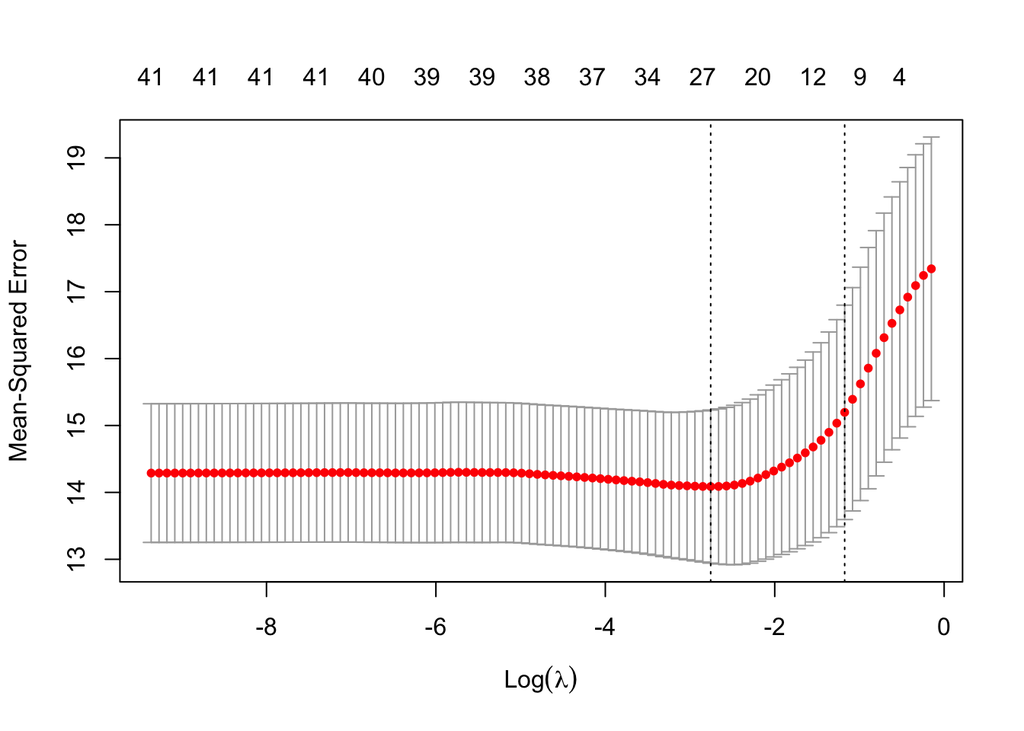

```r
plot(cv_model)
```

```r
best_model <- glmnet(x, y, alpha = 1, lambda = best_lambda)
coef(best_model)
```

```
## 43 x 1 sparse Matrix of class "dgCMatrix"
##                                                     s0
## (Intercept)                               12.005565402
## (Intercept)                                .
## UBPRE554                                   .
## UBPRE555                                   .
## UBPRE556                                   .
## UBPRE568                                   .
## UBPRE566                                   .
## UBPRE572                                   .
## UBPRE575                                  -0.003004275
## UBPRE589                                   0.047442216
## UBPRM026                                  -0.009237209
## UBPRM027                                   .
## UBPRM037                                   .
## UBPRM038                                   .
## UBPR4340                                   .
## UBPR7402                                   .
## UBPR7414                                   .
## UBPRE001                                   .
## UBPRE002                                   .
## UBPRE006                                   .
## UBPRE008                                   .
## UBPRE014                                  -0.004426105
## UBPRE015                                  -0.039395111
## UBPRE016                                   .
## UBPRE017                                   .
## UBPRE544                                   0.222540582
## UBPRE549                                   .
## UBPRE600                                   0.031210935
## UBPRK447                                   .
## OTSREGNMnortheast                          .
## OTSREGNMsoutheast                          .
## OTSREGNMwest                               .
## OTSREGNMwestern                            .
## REGAGNTFED                                 .
## REGAGNTOCC                                 .
## SPECGRPNAll.Other.Over.1.Billion           .
## SPECGRPNAll.Other.Under.1.Billion          .
## SPECGRPNCommercial.Lending.Specialization -0.362069360
## SPECGRPNConsumer.Lending.Specialization    .
## SPECGRPNCredit.card.Specialization         .
## SPECGRPNInternational.Specialization       .
## SPECGRPNMortgage.Lending.Specialization    0.504508096
## SPECGRPNOther.Specialized.Under.1.Billion  1.241485070
```

### Using the listed coefficient with non-zero effect, we can identify the following variables as the ones selected for out model:

- UBPRE575
- UBPRE589
- UBPRM026
- UBPRE014
- UBPRE015
- UBPRE544
- UBPRE600
- SPECGRPN

### With these selected variables, we can fit the data to the following regression model using a 5-fold cross validation:

```r
set.seed(1)
sel.names <- c("UBPRE575","UBPRE589","UBPRM026","UBPRE014","UBPRE015","UBPRE544","UBPRE600","SPECGRPN")

fit.lasso <- train(as.formula(paste("UBPRD486",paste(sel.names, collapse = "+"),sep=" ~ ")), method = "lm",
                     trControl = trainControl(method="cv", number=5, savePredictions = TRUE),
                     data=df)

summary(fit.lasso$finalModel)
```

```
##
## Call:
## lm(formula = .outcome ~ ., data = dat)
##
## Residuals:
##     Min      1Q  Median      3Q     Max
## -11.615  -1.961  -0.543   1.182  50.186
##
## Coefficients:
##                                            Estimate Std. Error t value Pr(>|t|)
## (Intercept)                               15.371595   1.520433  10.110  < 2e-16
## UBPRE575                                  -0.001730   0.005038  -0.343   0.7313
## UBPRE589                                   0.078242   0.008394   9.322  < 2e-16
## UBPRM026                                  -0.025207   0.003151  -8.000 1.58e-15
## UBPRE014                                  -0.045603   0.015014  -3.037   0.0024
## UBPRE015                                  -0.060019   0.005333 -11.254  < 2e-16
## UBPRE544                                   0.436990   0.061854   7.065 1.87e-12
## UBPRE600                                   0.062084   0.003233  19.206  < 2e-16
## SPECGRPNAll.Other.Over.1.Billion          -0.782223   0.465095  -1.682   0.0927
## SPECGRPNAll.Other.Under.1.Billion         -0.044277   0.221538  -0.200   0.8416
## SPECGRPNCommercial.Lending.Specialization -1.056788   0.149091  -7.088 1.58e-12
## SPECGRPNConsumer.Lending.Specialization   -1.381076   0.667056  -2.070   0.0385
## SPECGRPNCredit.card.Specialization         0.328471   1.267381   0.259   0.7955
## SPECGRPNInternational.Specialization      -3.591104   1.683604  -2.133   0.0330
## SPECGRPNMortgage.Lending.Specialization    1.517069   0.276384   5.489 4.27e-08
## SPECGRPNOther.Specialized.Under.1.Billion  2.591061   0.282746   9.164  < 2e-16
##
## (Intercept)                               ***
## UBPRE575
## UBPRE589                                  ***
## UBPRM026                                  ***
## UBPRE014                                  **
## UBPRE015                                  ***
## UBPRE544                                  ***
## UBPRE600                                  ***
## SPECGRPNAll.Other.Over.1.Billion          .
## SPECGRPNAll.Other.Under.1.Billion
## SPECGRPNCommercial.Lending.Specialization ***
## SPECGRPNConsumer.Lending.Specialization   *
## SPECGRPNCredit.card.Specialization
## SPECGRPNInternational.Specialization      *
## SPECGRPNMortgage.Lending.Specialization   ***
## SPECGRPNOther.Specialized.Under.1.Billion ***
## ---
## Signif. codes:  0 '***' 0.001 '**' 0.01 '*' 0.05 '.' 0.1 ' ' 1
##
## Residual standard error: 3.725 on 4307 degrees of freedom
## Multiple R-squared:  0.2028, Adjusted R-squared:  0.2001
## F-statistic: 73.06 on 15 and 4307 DF,  p-value: < 2.2e-16
```

From our output above, at a confidence level of $\alpha= 0.9$ we obtain the following regression equation for our final model:

$$\begin{align*}
&\text{UBPRD486}=15.371595 +0.078242*(UBPRE589) -0.025207*(UBPRM026)
-0.045603*(UBPRE014)\\
&-0.060019*(UBPRE015)+ 0.436990*(UBPRE544) +0.062084*(UBPRE600)
-0.782223*(SPECGRPN_{All.Other.Over.1.Billion})\\
&-1.056788*(SPECGRPN_{Commercial.Lending.Specialization})-1.381076*(SPECGRPN_{Consumer.Lending.Specialization})\\
&-3.591104*(SPECGRPN_{International.Specialization})
+1.517069*(SPECGRPN_{Mortgage.Lending.Specialization})\\
&+2.591061*(SPECGRPN_{Other.Specialized.Under.1.Billion })
\end{align*}$$

### We can then examine the predictive quality of our final model, both full and cross-validated:

Full model:

```r
predfin.lm <- predict(fit.lasso)
head(cbind(df$UBPRD486,predfin.lm))
```

```
##           predfin.lm
## 1 21.4857   12.92386
## 2  9.8415   10.89412
## 3 12.3113   13.28723
## 4 14.3916   15.53895
## 5  8.3719   11.82164
## 6  8.6575   10.23846
```

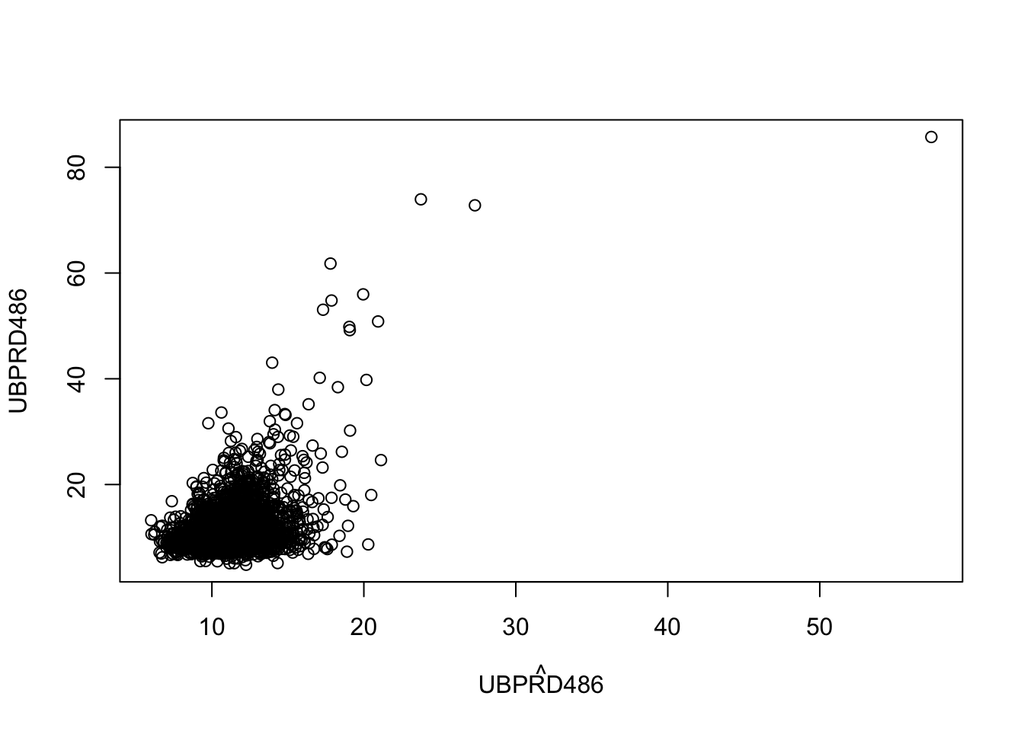

```r
plot(df$UBPRD486 ~ predfin.lm, xlab=expression(hat(UBPRD486)), ylab = "UBPRD486")
```

```r
cor(df$UBPRD486, predfin.lm)
```

```
## [1] 0.4503755
```

Cross-validated:

```r
pred.lm <- fit.lasso$pred
head(cbind(df$UBPRD486[pred.lm$rowIndex],pred.lm$pred))
```

```
##         [,1]      [,2]
## [1,]  8.3719 11.469250
## [2,] 15.2321 10.361204
## [3,] 12.8722 11.344071
## [4,] 10.9154  9.990514
## [5,] 15.1772 13.904823
## [6,] 11.4926  9.774541
```

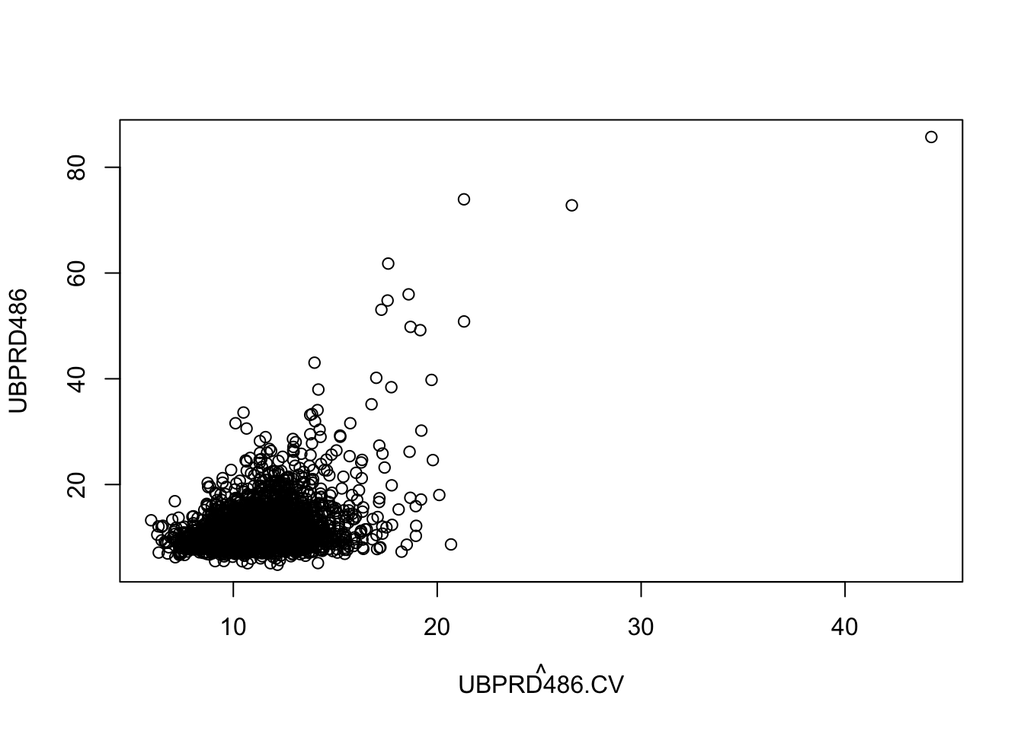

```r
plot(df$UBPRD486[pred.lm$rowIndex] ~ pred.lm$pred, xlab=expression(hat(UBPRD486.CV)), ylab = "UBPRD486")
```

```r
cor(df$UBPRD486[pred.lm$rowIndex], pred.lm$pred)
```

```
## [1] 0.4215608
```

In both cases, our correlation is not very strong — $<0.5$.

### We can now check to see if our final model has any multicollinearity problems:

```r
vif(fit.lasso$finalModel)
```

```
##                                  UBPRE575
##                                  1.755714
##                                  UBPRE589
##                                  2.106960
##                                  UBPRM026
##                                  1.135909
##                                  UBPRE014
##                                  1.078724
##                                  UBPRE015
##                                  1.155514
##                                  UBPRE544
##                                  1.070266
##                                  UBPRE600
##                                  1.790473
##          SPECGRPNAll.Other.Over.1.Billion
##                                  1.073357
##         SPECGRPNAll.Other.Under.1.Billion
##                                  1.326681
## SPECGRPNCommercial.Lending.Specialization
##                                  1.722316
##   SPECGRPNConsumer.Lending.Specialization
##                                  1.049937
##        SPECGRPNCredit.card.Specialization
##                                  1.039453
##      SPECGRPNInternational.Specialization
##                                  1.020001
##   SPECGRPNMortgage.Lending.Specialization
##                                  1.272059
## SPECGRPNOther.Specialized.Under.1.Billion
##                                  1.361891
```

We see that no values surpass the VIF threshold so there is no multicollinearity issue.

### Model Assumptions

Independence: The banks sampled for this dataset are almost certainly not independent, as they likely have significant influence over other banks’ policies, resulting in influenced data points.

Linearity:

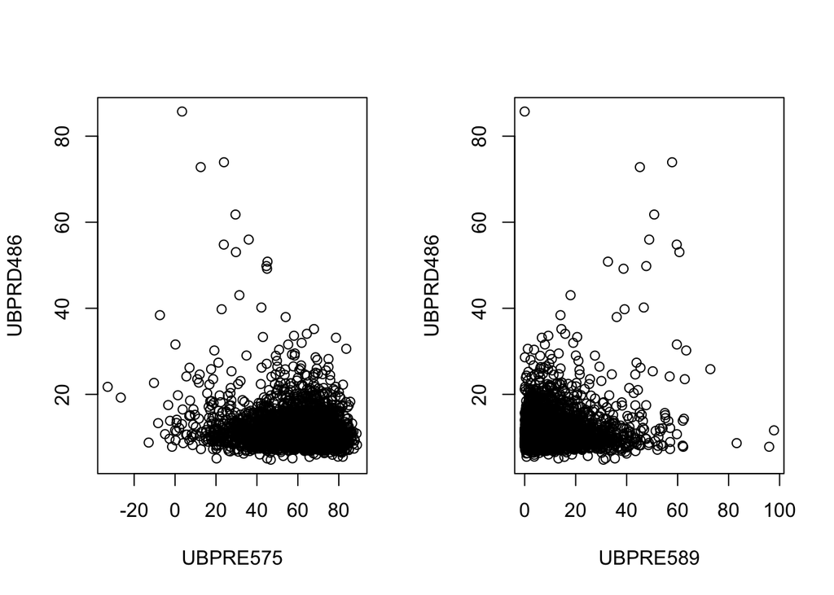

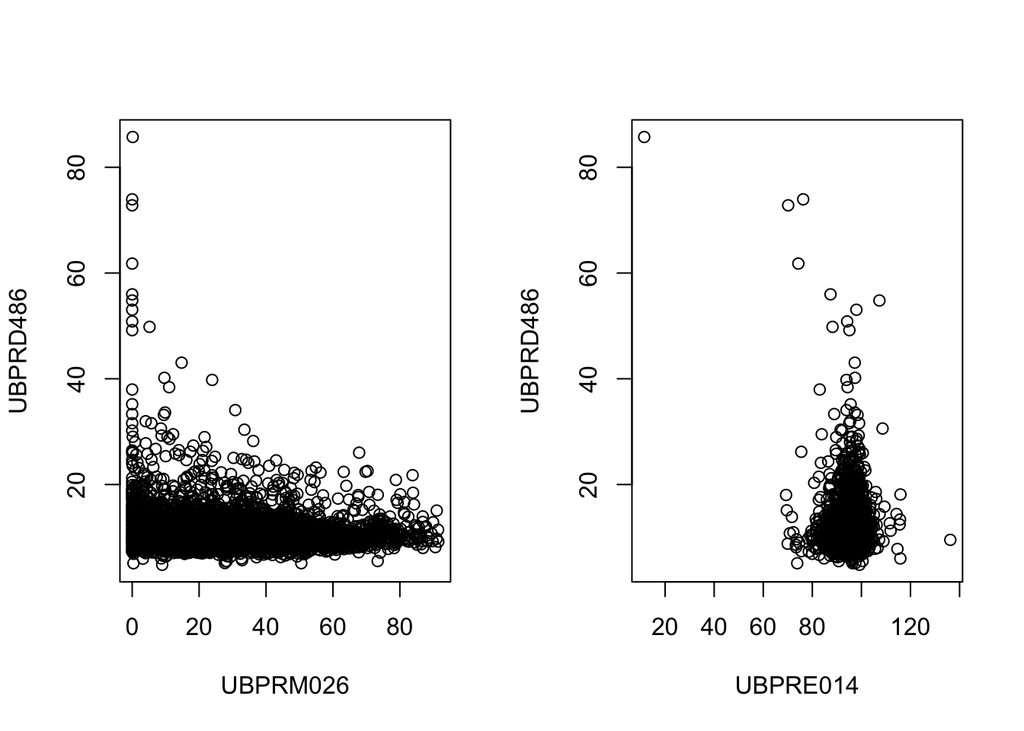

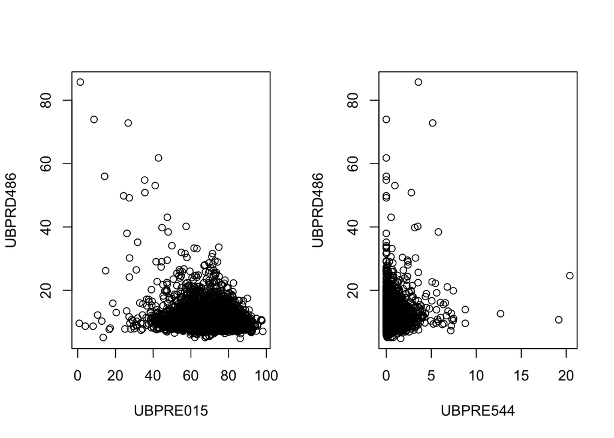

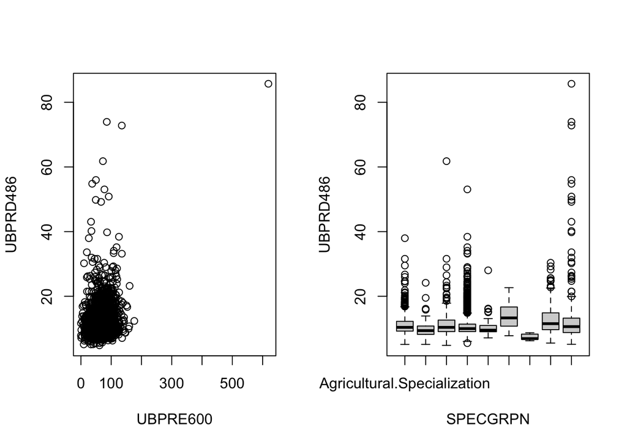

```r
par(mfrow = c(1, 2))
plot(as.formula(paste("UBPRD486",paste(sel.names, collapse = "+"),sep=" ~ ")), data=df)
```

None of the above scatterplots indicate linearity between our covariates and our dependent variable. This lack of support seems to moreso be a result of outliers than a different relationship like logarithmic.

Constant variance:

```r
ncvTest(fit.lasso$finalModel)
```

```
## Non-constant Variance Score Test
## Variance formula: ~ fitted.values
## Chisquare = 8684.504, Df = 1, p = < 2.22e-16
```

We reject the null hypothesis of homoscedasticity with the BP test below, indicating that variance is non-constant.

Normality:

```r
shapiro.test(rstandard(fit.lasso$finalModel))
```

```
##
##  Shapiro-Wilk normality test
##
## data:  rstandard(fit.lasso$finalModel)
## W = 0.76225, p-value < 2.2e-16
```

We reject the null hypothesis and conclude that there is evidence that the residuals depart from normality.

#### Remove outliers

Visualize the studentized residuals that are outside of the range of [-3,3]

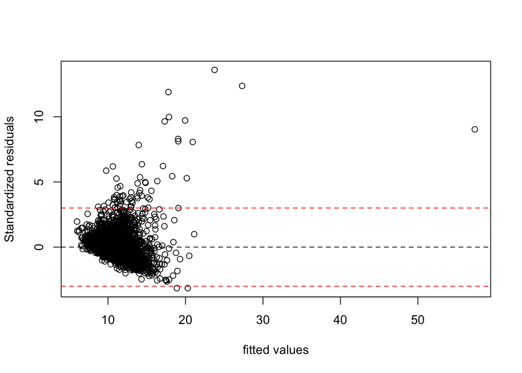

```r
plot(rstandard(fit.lasso$finalModel) ~ fit.lasso$finalModel$fitted.values,
     xlab="fitted values", ylab="Standardized residuals")
abline(0,0, lty=2)
abline(-3, 0, lty=2, col="red")
abline(3, 0, lty=2, col="red")
```

Remove the points outside of those bounds:

```r
i <- 1
indices <- c()
for(val in rstandard(fit.lasso$finalModel)){
  if(val > 3 || val < -3){
    indices <- append(indices, i)
  }
  i <- i + 1
}

df.OL <- df[-indices,]
```

Refit the cross-validated model with the removed outliers:

```r
fit.lasso.outlier <- train(as.formula(paste("UBPRD486",paste(sel.names, collapse = "+"),sep=" ~ ")),
                           method = "lm",
                           trControl = trainControl(method="cv", number=5, savePredictions = TRUE),
                           data=df.OL)

summary(fit.lasso$finalModel)
```

```
##
## Call:
## lm(formula = .outcome ~ ., data = dat)
##
## Residuals:
##     Min      1Q  Median      3Q     Max
## -11.615  -1.961  -0.543   1.182  50.186
##
## Coefficients:
##                                            Estimate Std. Error t value Pr(>|t|)
## (Intercept)                               15.371595   1.520433  10.110  < 2e-16
## UBPRE575                                  -0.001730   0.005038  -0.343   0.7313
## UBPRE589                                   0.078242   0.008394   9.322  < 2e-16
## UBPRM026                                  -0.025207   0.003151  -8.000 1.58e-15
## UBPRE014                                  -0.045603   0.015014  -3.037   0.0024
## UBPRE015                                  -0.060019   0.005333 -11.254  < 2e-16
## UBPRE544                                   0.436990   0.061854   7.065 1.87e-12
## UBPRE600                                   0.062084   0.003233  19.206  < 2e-16
## SPECGRPNAll.Other.Over.1.Billion          -0.782223   0.465095  -1.682   0.0927
## SPECGRPNAll.Other.Under.1.Billion         -0.044277   0.221538  -0.200   0.8416
## SPECGRPNCommercial.Lending.Specialization -1.056788   0.149091  -7.088 1.58e-12
## SPECGRPNConsumer.Lending.Specialization   -1.381076   0.667056  -2.070   0.0385
## SPECGRPNCredit.card.Specialization         0.328471   1.267381   0.259   0.7955
## SPECGRPNInternational.Specialization      -3.591104   1.683604  -2.133   0.0330
## SPECGRPNMortgage.Lending.Specialization    1.517069   0.276384   5.489 4.27e-08
## SPECGRPNOther.Specialized.Under.1.Billion  2.591061   0.282746   9.164  < 2e-16
##
## (Intercept)                               ***
## UBPRE575
## UBPRE589                                  ***
## UBPRM026                                  ***
## UBPRE014                                  **
## UBPRE015                                  ***
## UBPRE544                                  ***
## UBPRE600                                  ***
## SPECGRPNAll.Other.Over.1.Billion          .
## SPECGRPNAll.Other.Under.1.Billion
## SPECGRPNCommercial.Lending.Specialization ***
## SPECGRPNConsumer.Lending.Specialization   *
## SPECGRPNCredit.card.Specialization
## SPECGRPNInternational.Specialization      *
## SPECGRPNMortgage.Lending.Specialization   ***
## SPECGRPNOther.Specialized.Under.1.Billion ***
## ---
## Signif. codes:  0 '***' 0.001 '**' 0.01 '*' 0.05 '.' 0.1 ' ' 1
##
## Residual standard error: 3.725 on 4307 degrees of freedom
## Multiple R-squared:  0.2028, Adjusted R-squared:  0.2001
## F-statistic: 73.06 on 15 and 4307 DF,  p-value: < 2.2e-16
```

Check the predictive quality:

```r
predfin.lm <- predict(fit.lasso.outlier)
head(cbind(df.OL$UBPRD486,predfin.lm))
```

```
##           predfin.lm
## 1 21.4857   11.88451
## 2  9.8415   11.35831
## 3 12.3113   13.02215
## 4 14.3916   13.63511
## 5  8.3719   10.99914
## 6  8.6575   10.00098
```

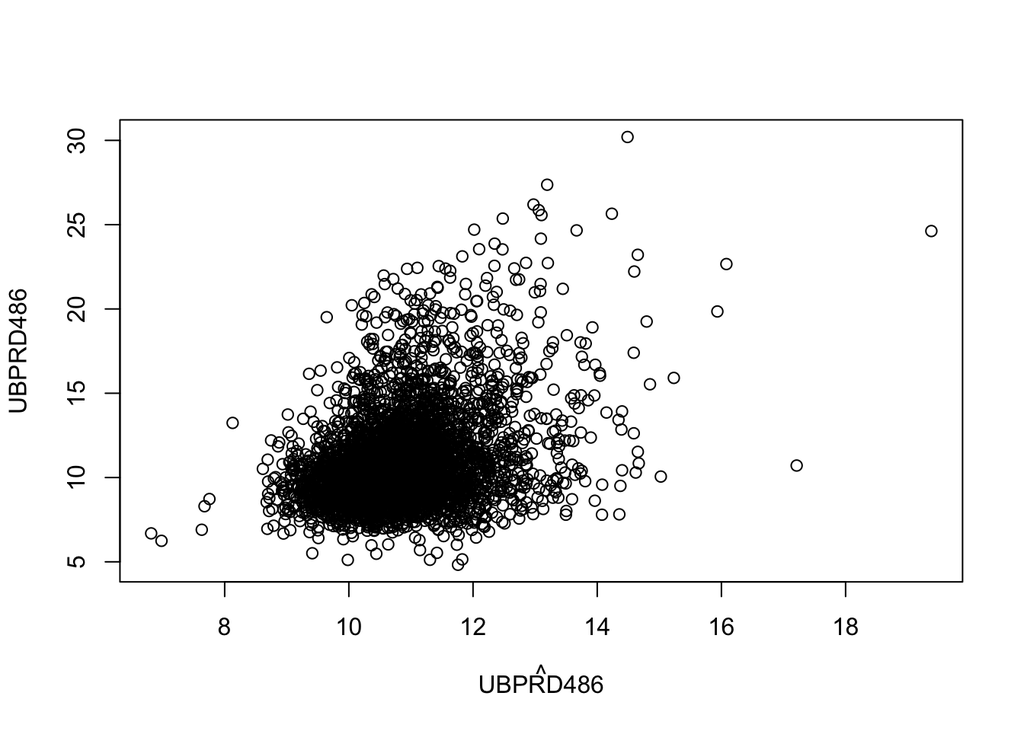

```r
plot(df.OL$UBPRD486 ~ predfin.lm, xlab=expression(hat(UBPRD486)), ylab = "UBPRD486")
```

```r
cor(df.OL$UBPRD486, predfin.lm)
```

```
## [1] 0.338279
```

The scatter plot seems to be more coorelated, but the correlation is significantly worse than the previous model.